# 02 — Construcción del dataset integrado

A partir del EDA (`01_EDA.ipynb`) construimos un único dataset con una fila por cada combinación `(idTram, timestamp_hora)` que incluye:

| Bloque | Fuente | Resolución original → horaria |
| --- | --- | --- |
| Tráfico | Itineraris CSV | ~5 min → media horaria |
| Meteorología | MeteoCat CSV | Diaria → broadcast a horas del día |
| Eventos culturales | Agenda cultural + Agenda actividades | Fecha inicio/fin → flag horario |
| Festivales / Fiestas | Festivales CSV | Fecha inicio/fin → flag horario |
| Accidentes | Accidents CSV | Por hora → conteo horario |
| Rasgos temporales | Derivados | — |

**Output:** `../dataset/integrated/dataset_integrado_horario.parquet`

## 0. Imports y configuración

```python
import warnings
import os
import glob
from pathlib import Path

import numpy as np
import pandas as pd

warnings.filterwarnings('ignore')
pd.set_option('display.max_columns', 50)
pd.set_option('display.float_format', '{:.4f}'.format)

# Rutas base
DATA_DIR = Path('../dataset')
OUT_DIR  = DATA_DIR / 'integrated'
OUT_DIR.mkdir(parents=True, exist_ok=True)

print('Data dir:', DATA_DIR.resolve())
print('Output dir:', OUT_DIR.resolve())
```

```
Data dir: C:\src\prediccion-trafico-por-evento\dataset
Output dir: C:\src\prediccion-trafico-por-evento\dataset\integrated
```

## 1. Tráfico — carga y agregación horaria

Cargamos todos los CSV de Itineraris (2021-2024), filtramos registros con `infoDisponible=1`, sustituimos -1 por NaN y resampleamos a granularidad horaria por `idTram`.

```python
TRAFICO_GLOB = str(DATA_DIR / 'Itineraris' / '*_ITINERARIS_ITINERARIS.csv')

archivos = sorted(glob.glob(TRAFICO_GLOB))
print(f'Archivos encontrados: {len(archivos)}')

# Columnas de interés
COLS_TRAFICO = ['idTram', 'infoDisponible', 'data',
                'tempsActual', 'tempsPrevist',
                'factorReferenciaActual', 'tendencia']

def cargar_mes_trafico(path: str) -> pd.DataFrame:
    """Carga un CSV mensual de Itineraris y aplica limpieza básica."""
    df = pd.read_csv(path, usecols=COLS_TRAFICO, low_memory=False)
    # Parsear timestamp
    df['timestamp'] = pd.to_datetime(df['data'].astype(str), format='%Y%m%d%H%M%S', errors='coerce')
    df = df.drop(columns='data')
    # Filtrar solo registros con datos disponibles
    df = df[df['infoDisponible'] == 1].copy()
    df = df.drop(columns='infoDisponible')
    # Reemplazar -1 por NaN
    for col in ['tempsActual', 'tempsPrevist', 'factorReferenciaActual', 'tendencia']:
        df[col] = df[col].replace(-1, np.nan)
    return df

# Carga incremental por archivo
chunks = []
for path in archivos:
    try:
        chunks.append(cargar_mes_trafico(path))
    except Exception as e:
        print(f'  ERROR {Path(path).name}: {e}')

trafico_raw = pd.concat(chunks, ignore_index=True)
print(f'\nRegistros cargados (infoDisponible=1): {len(trafico_raw):,}')
print(f'Rango temporal: {trafico_raw.timestamp.min()} → {trafico_raw.timestamp.max()}')
print(f'Trams únicos: {trafico_raw.idTram.nunique()}')
trafico_raw.head(3)
```

```
Archivos encontrados: 40

Registros cargados (infoDisponible=1): 15,674,546
Rango temporal: 2021-01-01 00:05:52 → 2024-12-31 23:50:54
Trams únicos: 58
```

|  | idTram | tempsActual | tempsPrevist | factorReferenciaActual | tendencia | timestamp |
| --- | --- | --- | --- | --- | --- | --- |
| 0 | 1 | 300 | 300 | 1.0000 | 1.0000 | 2021-01-01 00:05:52 |
| 1 | 2 | 255 | 255 | 1.0000 | 1.0000 | 2021-01-01 00:05:52 |
| 2 | 3 | 304 | 305 | 1.0000 | 1.0000 | 2021-01-01 00:05:52 |

> `trafico_raw` contiene todos los registros de Itineraris de los CSV encontrados para el periodo completo (pre-filtrado). Cada fila es una medicion puntual de un tramo con columnas `idTram`, `timestamp`, `factorReferenciaActual`, `tempsActual`, `tempsPrevist` y `tendencia`. Los valores `-1` han sido sustituidos por `NaN` y los registros con `infoDisponible != 1` descartados.

```python
# Truncar al periodo de interés: 2021-01-01 → 2024-12-31
trafico_raw = trafico_raw[
    (trafico_raw.timestamp >= '2021-01-01') &
    (trafico_raw.timestamp < '2025-01-01')
].copy()

# Crear columna de hora (truncada al inicio de la hora)
trafico_raw['hora'] = trafico_raw['timestamp'].dt.floor('h')

# Agregar a granularidad horaria por tram
trafico_horario = (
    trafico_raw
    .groupby(['idTram', 'hora'])
    .agg(
        factor_medio     = ('factorReferenciaActual', 'mean'),
        factor_max       = ('factorReferenciaActual', 'max'),
        factor_min       = ('factorReferenciaActual', 'min'),
        factor_std       = ('factorReferenciaActual', 'std'),
        tiempo_actual    = ('tempsActual',            'mean'),
        tiempo_previsto  = ('tempsPrevist',           'mean'),
        tendencia_media  = ('tendencia',              'mean'),
        n_mediciones     = ('factorReferenciaActual', 'count'),
    )
    .reset_index()
)

print(f'Filas dataset tráfico horario: {len(trafico_horario):,}')
print(f'Nulos en factor_medio: {trafico_horario.factor_medio.isna().sum():,}')
trafico_horario.head(3)
```

```
Filas dataset tráfico horario: 1,566,884
Nulos en factor_medio: 272,976
```

|  | idTram | hora | factor_medio | factor_max | factor_min | factor_std | tiempo_actual | tiempo_previsto | tendencia_media | n_mediciones |
| --- | --- | --- | --- | --- | --- | --- | --- | --- | --- | --- |
| 0 | 1 | 2021-01-01 00:00:00 | 1.0000 | 1.0000 | 1.0000 | 0.0000 | 302.0000 | 301.4167 | 1.0000 | 12 |
| 1 | 1 | 2021-01-01 01:00:00 | 1.0000 | 1.0000 | 1.0000 | 0.0000 | 301.1667 | 301.4167 | 1.0000 | 12 |
| 2 | 1 | 2021-01-01 02:00:00 | 1.0000 | 1.0000 | 1.0000 | 0.0000 | 300.0833 | 300.0000 | 1.0000 | 12 |

> Esta tabla es la **base del dataset final**: cada tram x hora genera una fila.

### 1.2 Diagnóstico de fiabilidad de sensores de tráfico

Los sensores de los tramos (Itineraris) pueden fallar de dos maneras principales:

- **Corte total** — el sensor deja de transmitir → aparecen `NaN` en `factor_medio`. Se detecta como porcentaje de nulos > 20 % en un mes × tram.
- **Lecturas anómalas** — el sensor transmite pero los valores no son coherentes con el comportamiento histórico del propio tramo o con sus vecinos del mismo corredor.

Se aplican **dos modelos complementarios** para detectar lecturas anómalas:

1. **Isolation Forest por tramo** — aprende el perfil normal de cada sensor (factor, desviación respecto a su propia media rolling, mediciones, hora del día). Puntúa cada hora según cuánto se aleja del comportamiento habitual del propio tramo. Contamination = 5 %.
2. **Peer comparison por corredor** — para cada hora, compara el factor de un tramo con la media de los otros tramos del mismo itinerario. Si el residuo supera 3σ respecto al error habitual del corredor, se marca como sospechoso. Distingue eventos reales de tráfico (todos los tramos del corredor suben juntos) de fallos de sensor (solo uno diverge).

El flag final `sensor_trafico_ok` (1 = fiable, 0 = sospechoso) se activa si **cualquiera** de las tres señales detecta un problema.

```
Isolation Forest : 64,049 horas anómalas (4.1 %)
Peer comparison  : 3,027 horas anómalas (0.5 %)

Horas sospechosas totales : 356,456 de 1,566,884 (22.7 %)

Meses con >20% nulos (top 10):
 idTram anyo_mes  null_pct  null_excesivo
     60  2024-05  100.0000           True
     57  2024-12  100.0000           True
     57  2024-11  100.0000           True
     57  2024-10  100.0000           True
     57  2024-09  100.0000           True
     57  2024-08  100.0000           True
     57  2024-07  100.0000           True
     11  2021-01  100.0000           True
      7  2022-10  100.0000           True
      6  2023-01  100.0000           True
```

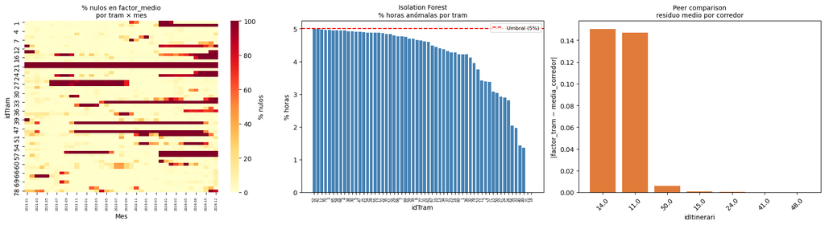

```python
import matplotlib.pyplot as plt
import seaborn as sns
import numpy as np
from sklearn.ensemble import IsolationForest

# ── Parámetros ────────────────────────────────────────────────────────────────
NULL_UMBRAL  = 20    # % nulos en un mes × tram → periodo malo
ROLL_WIN     = 24    # ventana rolling para media propia del tram (horas)
IF_CONTAM    = 0.05  # fracción esperada de anomalías en Isolation Forest
PEER_ZSCORE  = 3.0   # desviaciones sobre el error del corredor → sospechoso

trafico_diag = trafico_horario.copy()
trafico_diag["anyo_mes"]   = trafico_diag["hora"].dt.to_period("M")
trafico_diag["hora_dia"]   = trafico_diag["hora"].dt.hour
trafico_diag["dia_semana"] = trafico_diag["hora"].dt.dayofweek
trafico_diag = trafico_diag.sort_values(["idTram", "hora"]).reset_index(drop=True)

# ── 1. Tasa de nulos por mes × tram ──────────────────────────────────────────
null_tram_mes = (
    trafico_diag.groupby(["idTram", "anyo_mes"])["factor_medio"]
    .apply(lambda g: g.isnull().mean() * 100)
    .round(1)
    .reset_index(name="null_pct")
)
null_tram_mes["null_excesivo"] = null_tram_mes["null_pct"] > NULL_UMBRAL

# ── 2. Isolation Forest por tramo ────────────────────────────────────────────
# Features: desviación del factor respecto a la media rolling propia del tramo,
# n_mediciones y contexto temporal. Evita el falso positivo de std=0 sobre 1.0.
trafico_diag["roll_mean"] = (
    trafico_diag.groupby("idTram")["factor_medio"]
    .transform(lambda s: s.rolling(ROLL_WIN, min_periods=6).mean())
)
trafico_diag["desv_roll"] = (
    (trafico_diag["factor_medio"] - trafico_diag["roll_mean"]).abs()
)

feat_if = ["factor_medio", "desv_roll", "n_mediciones", "hora_dia", "dia_semana"]
trafico_diag["if_anomalia"] = 0

for tram_id, grp in trafico_diag.groupby("idTram"):
    mask_ok = grp[feat_if].notna().all(axis=1)
    if mask_ok.sum() < 50:
        continue
    X = grp.loc[mask_ok, feat_if].fillna(0)
    clf = IsolationForest(contamination=IF_CONTAM, random_state=42, n_jobs=-1)
    preds = clf.fit_predict(X)              # -1 = anomalía, 1 = normal
    trafico_diag.loc[X.index, "if_anomalia"] = (preds == -1).astype(int)

n_if = trafico_diag["if_anomalia"].sum()
print(f"Isolation Forest : {n_if:,} horas anómalas "
      f"({n_if / len(trafico_diag) * 100:.1f} %)")

# ── 3. Peer comparison por corredor ──────────────────────────────────────────
# Media del corredor = media de los otros tramos del mismo itinerario en esa hora.
# Residuo alto y atípico → sospechoso.
tram_it = (
    trafico_diag[["idTram", "hora", "hora_dia", "factor_medio"]]
    .merge(tram_itinerari[["idTram", "idItinerari"]], on="idTram", how="left")
    .dropna(subset=["idItinerari"])
)

corredor_mean = tram_it.groupby(["idItinerari", "hora"])["factor_medio"].transform("mean")
n_corredor    = tram_it.groupby(["idItinerari", "hora"])["factor_medio"].transform("count")

tram_it["peer_residuo"] = np.where(
    n_corredor >= 2,
    (tram_it["factor_medio"] - corredor_mean).abs(),
    np.nan,
)

# Z-score del residuo dentro de cada (corredor, hora del día)
tram_it["peer_z"] = (
    tram_it.groupby(["idItinerari", "hora_dia"])["peer_residuo"]
    .transform(lambda s: (s - s.mean()) / (s.std() + 1e-9))
)
tram_it["peer_anomalia"] = (tram_it["peer_z"] > PEER_ZSCORE).astype(int)

n_peer = tram_it["peer_anomalia"].sum()
print(f"Peer comparison  : {n_peer:,} horas anómalas "
      f"({n_peer / len(tram_it) * 100:.1f} %)")

# ── 4. Flag final: sensor_trafico_ok ─────────────────────────────────────────
trafico_horario = trafico_horario.copy()
trafico_horario["anyo_mes"] = trafico_horario["hora"].dt.to_period("M")

trafico_horario = trafico_horario.merge(
    null_tram_mes[["idTram", "anyo_mes", "null_excesivo"]],
    on=["idTram", "anyo_mes"], how="left"
)
trafico_horario["null_excesivo"] = trafico_horario["null_excesivo"].fillna(False)

trafico_horario = trafico_horario.merge(
    trafico_diag[["idTram", "hora", "if_anomalia"]],
    on=["idTram", "hora"], how="left"
)
trafico_horario["if_anomalia"] = trafico_horario["if_anomalia"].fillna(0).astype(int)

peer_flags = (
    tram_it[["idTram", "hora", "peer_anomalia"]]
    .drop_duplicates(["idTram", "hora"])
)
trafico_horario = trafico_horario.merge(
    peer_flags, on=["idTram", "hora"], how="left"
)
trafico_horario["peer_anomalia"] = trafico_horario["peer_anomalia"].fillna(0).astype(int)

trafico_horario["sensor_trafico_ok"] = (
    ~trafico_horario["null_excesivo"]
    & (trafico_horario["if_anomalia"]   == 0)
    & (trafico_horario["peer_anomalia"] == 0)
).astype(int)

trafico_horario = trafico_horario.drop(
    columns=["anyo_mes", "null_excesivo", "if_anomalia", "peer_anomalia"]
)

n_malas = (trafico_horario["sensor_trafico_ok"] == 0).sum()
print(f"\nHoras sospechosas totales : {n_malas:,} de {len(trafico_horario):,} "
      f"({n_malas / len(trafico_horario) * 100:.1f} %)")
print(f"\nMeses con >{NULL_UMBRAL}% nulos (top 10):")
print(
    null_tram_mes[null_tram_mes["null_excesivo"]]
    .sort_values("null_pct", ascending=False)
    .head(10)
    .to_string(index=False)
)

# ── 5. Visualización ─────────────────────────────────────────────────────────
fig, axes = plt.subplots(1, 3, figsize=(18, 5))

# Panel 1: Heatmap nulos
pivot_null = (
    null_tram_mes.pivot(index="idTram", columns="anyo_mes", values="null_pct")
    .fillna(0)
)
sns.heatmap(pivot_null, ax=axes[0], cmap="YlOrRd", vmin=0, vmax=100,
            linewidths=0, cbar_kws={"label": "% nulos"})
axes[0].set_title("% nulos en factor_medio\npor tram × mes", fontsize=10)
axes[0].set_xlabel("Mes"); axes[0].set_ylabel("idTram")
axes[0].tick_params(axis="x", rotation=90, labelsize=5)

# Panel 2: Isolation Forest — % anómalas por tram
if_por_tram = (
    trafico_diag.groupby("idTram")["if_anomalia"]
    .mean().mul(100).sort_values(ascending=False)
)
axes[1].bar(if_por_tram.index.astype(str), if_por_tram.values, color="steelblue")
axes[1].axhline(IF_CONTAM * 100, color="red", linestyle="--",
                label=f"Umbral ({IF_CONTAM*100:.0f}%)")
axes[1].set_title("Isolation Forest\n% horas anómalas por tram", fontsize=10)
axes[1].set_xlabel("idTram"); axes[1].set_ylabel("% horas")
axes[1].tick_params(axis="x", rotation=90, labelsize=6)
axes[1].legend(fontsize=8)

# Panel 3: Peer comparison — residuo medio por corredor
peer_by_it = (
    tram_it.dropna(subset=["peer_residuo"])
    .groupby("idItinerari")["peer_residuo"]
    .mean()
    .sort_values(ascending=False)
)
axes[2].bar(peer_by_it.index.astype(str), peer_by_it.values, color="#e07b39")
axes[2].set_title("Peer comparison\nresiduo medio por corredor", fontsize=10)
axes[2].set_xlabel("idItinerari")
axes[2].set_ylabel("|factor_tram − media_corredor|")
axes[2].tick_params(axis="x", rotation=45)

plt.tight_layout()
plt.show()
```

**Panel izquierdo — Heatmap de % nulos por tram × mes**

Muestra la tasa de valores nulos en factor_medio para cada combinación de tramo y mes. Los tramos con filas completamente rojas (100 % de nulos durante meses o años seguidos) corresponden a sensores con cortes de cobertura prolongados. Varios tramos presentan este patrón, especialmente el tram 21. Se aprecia una banda de mayor densidad de nulos en 2023, que afecta a múltiples tramos de forma simultánea, lo que sugiere un problema sistémico puntual en la infraestructura de recogida de datos. La mayoría de los tramos tienen fondo amarillo claro (0–10 % de nulos) con celdas oscuras aisladas que indican cortes breves de 1–2 meses.

**Panel central — Isolation Forest: % horas anómalas por tram**

El modelo Isolation Forest, entrenado de forma independiente para cada tramo con features de factor, desviación respecto a su propia media rolling, número de mediciones y contexto horario, clasifica entre el 1 % y el 5 % de las horas de cada tramo como anómalas. La distribución decrece gradualmente de izquierda a derecha: los tramos de la izquierda tienen un comportamiento más irregular (más horas difíciles de explicar por su propio historial), mientras que los de la derecha son altamente predecibles. La línea roja discontinua marca el umbral de contaminación del 5 % configurado en el modelo.

**Panel derecho — Peer comparison: residuo medio por corredor**

Para cada itinerario que contiene al menos dos tramos monitorizados, se calcula cuánto difiere de media el factor de un tramo respecto a la media de sus vecinos del mismo corredor en cada hora. Los corredores 14 y 11 presentan un residuo medio de ~0.14–0.15, indicando que los tramos que los componen dan lecturas sistemáticamente distintas entre sí para una misma hora. El corredor 50 tiene un residuo de ~0.005 y los corredores 15, 24, 41 y 48 presentan valores prácticamente nulos, lo que significa que sus tramos se mueven de forma casi idéntica. Un residuo alto en un corredor puede deberse a sensores con comportamiento inconsistente entre tramos vecinos o a geometrías viales que generan patrones de tráfico estructuralmente distintos dentro del mismo corredor.

## 2. Meteorología — preparación horaria

Los datos de MeteoCat son diarios (una fila por estación × variable × día). Los pivotamos a wide (una fila por estación × día), promediamos las 4 estaciones y luego generamos una fila por hora del día mediante broadcast.

```python
METEO_GLOB = str(DATA_DIR / 'Meteorología' / '*MeteoCat_Detall_Estacions*.csv')
archivos_meteo = sorted(glob.glob(METEO_GLOB))
print(f'Archivos meteorología: {len(archivos_meteo)}')

meteo_raw = pd.concat(
    [pd.read_csv(p, encoding='utf-8', low_memory=False) for p in archivos_meteo],
    ignore_index=True
)

meteo_raw['DATA_LECTURA'] = pd.to_datetime(meteo_raw['DATA_LECTURA'], errors='coerce')
meteo_raw = meteo_raw.dropna(subset=['DATA_LECTURA', 'ACRÒNIM', 'VALOR'])
meteo_raw['fecha'] = meteo_raw['DATA_LECTURA'].dt.normalize()

print(f'Registros meteo: {len(meteo_raw):,}')
print('Variables disponibles:', sorted(meteo_raw['ACRÒNIM'].unique()))
meteo_raw.head(3)
```

```
Archivos meteorología: 4
Registros meteo: 73,929
Variables disponibles: ['DVM10', 'DVVX10', 'HRM', 'HRN', 'HRX', 'PM', 'PN', 'PPT', 'PX', 'RS24h', 'TM', 'TN', 'TX', 'VVM10', 'VVX10']
```

|  | DATA_LECTURA | DATA_EXTREM | CODI_ESTACIO | ACRÒNIM | VALOR | fecha |
| --- | --- | --- | --- | --- | --- | --- |
| 0 | 2021-01-01 | NaN | D5 | TM | 5.3000 | 2021-01-01 |
| 1 | 2021-01-01 | 13:06:00 | D5 | TX | 6.5000 | 2021-01-01 |
| 2 | 2021-01-01 | 23:56:00 | D5 | TN | 3.1000 | 2021-01-01 |

> `meteo_raw` con todos los registros de MeteoCat en formato largo (`DATA_LECTURA`, `ACRONIM`, `VALOR`). Las variables disponibles indican que magnitudes meteorologicas tienen cobertura real en el periodo 2021-2024 (temperatura, humedad, precipitacion, viento, presion). Los registros sin fecha o sin variable se han descartado.

```python
# Seleccionamos variables meteorológicas relevantes para el modelo
VARS_METEO = ['TM', 'TX', 'TN', 'HRM', 'PPT', 'VVM10', 'PM']

meteo_filtrado = meteo_raw[meteo_raw['ACRÒNIM'].isin(VARS_METEO)].copy()

# Pivotar: filas=fecha, columnas=variable (media sobre estaciones)
meteo_diario = (
    meteo_filtrado
    .groupby(['fecha', 'ACRÒNIM'])['VALOR']
    .mean()
    .unstack('ACRÒNIM')
    .reset_index()
)

# Renombrar columnas para mayor claridad
rename_meteo = {
    'TM':     'temp_media_c',
    'TX':     'temp_max_c',
    'TN':     'temp_min_c',
    'HRM':    'humedad_rel_pct',
    'PPT':    'precipitacion_mm',
    'VVM10':  'viento_vel_ms',
    'PM':     'presion_hpa',
}
meteo_diario = meteo_diario.rename(columns=rename_meteo)

# Flag lluvia (precipitación > 0.2 mm)
if 'precipitacion_mm' in meteo_diario.columns:
    meteo_diario['lluvia'] = (meteo_diario['precipitacion_mm'] > 0.2).astype(int)

# Restricción temporal 2021-2024
meteo_diario = meteo_diario[
    (meteo_diario['fecha'] >= '2021-01-01') &
    (meteo_diario['fecha'] < '2025-01-01')
].copy()

print(f'Días con datos meteo: {len(meteo_diario):,}')
meteo_diario.head(3)
```

```
Días con datos meteo: 1,461
```

| ACRÒNIM | fecha | humedad_rel_pct | presion_hpa | precipitacion_mm | temp_media_c | temp_min_c | temp_max_c | viento_vel_ms | lluvia |
| --- | --- | --- | --- | --- | --- | --- | --- | --- | --- |
| 0 | 2021-01-01 | 67.5000 | 984.2333 | 0.4333 | 7.6500 | 5.5250 | 9.1000 | 3.3000 | 1 |
| 1 | 2021-01-02 | 61.2500 | 985.0000 | 0.0000 | 5.9000 | 2.8500 | 9.4000 | 4.1000 | 0 |
| 2 | 2021-01-03 | 49.2500 | 988.8333 | 0.0000 | 5.3250 | 2.5750 | 9.8000 | 3.3000 | 0 |

> `meteo_diario` — tabla en formato **wide** con una fila por dia y una columna por variable meteorologica (media sobre todas las estaciones disponibles). Las columnas se han renombrado a nombres descriptivos (`temp_media_c`, `precipitacion_mm`, etc.) y se ha anadido el flag binario `lluvia` (precipitacion > 0.2 mm).

```python
# Expandir datos diarios a granularidad horaria
# Cada día genera 24 filas (una por hora 00:00-23:00)
horas = pd.DataFrame({'offset_horas': range(24)})
meteo_diario['_key'] = 1
horas['_key'] = 1

meteo_horario = meteo_diario.merge(horas, on='_key').drop(columns='_key')
meteo_horario['hora'] = (
    meteo_horario['fecha'] +
    pd.to_timedelta(meteo_horario['offset_horas'], unit='h')
)
meteo_horario = meteo_horario.drop(columns=['fecha', 'offset_horas'])

print(f'Filas meteo horario: {len(meteo_horario):,}')
meteo_horario.head(3)
```

```
Filas meteo horario: 35,064
```

|  | humedad_rel_pct | presion_hpa | precipitacion_mm | temp_media_c | temp_min_c | temp_max_c | viento_vel_ms | lluvia | hora |
| --- | --- | --- | --- | --- | --- | --- | --- | --- | --- |
| 0 | 67.5000 | 984.2333 | 0.4333 | 7.6500 | 5.5250 | 9.1000 | 3.3000 | 1 | 2021-01-01 00:00:00 |
| 1 | 67.5000 | 984.2333 | 0.4333 | 7.6500 | 5.5250 | 9.1000 | 3.3000 | 1 | 2021-01-01 01:00:00 |
| 2 | 67.5000 | 984.2333 | 0.4333 | 7.6500 | 5.5250 | 9.1000 | 3.3000 | 1 | 2021-01-01 02:00:00 |

> `meteo_horario` — expansion de `meteo_diario` a granularidad horaria mediante producto cartesiano con las 24 horas del día. Cada día meteorologico genera 24 filas identicas en las variables climaticas, con la columna `hora` como clave de union con el dataset de trafico. Esto asume que las condiciones meteorologicas diarias se aplican de forma uniforme a todas las horas.

## 3. Eventos — preparación horaria

Para cada hora calculamos: número de eventos activos, si hay festival de gran escala, tipo de evento predominante.

```python
# --- 3.1 Festivales y Fiestas ---
fest_glob = str(DATA_DIR / 'Festivales' / '*.csv')
fies_glob = str(DATA_DIR / 'Fiestas' / '*.csv')

dfs_fest = []
for pattern in [fest_glob, fies_glob]:
    for path in glob.glob(pattern):
        try:
            dfs_fest.append(pd.read_csv(path, encoding='latin-1', sep=',', low_memory=False))
        except Exception:
            dfs_fest.append(pd.read_csv(path, encoding='utf-8', sep=',', low_memory=False))

festivales = pd.concat(dfs_fest, ignore_index=True)

festivales['DataInici'] = pd.to_datetime(festivales['DataInici'], format='%d/%m/%Y', errors='coerce')
festivales['DataFi']    = pd.to_datetime(festivales['DataFi'],    format='%d/%m/%Y', errors='coerce')
# Si no hay fecha fin, usar la de inicio
festivales['DataFi'] = festivales['DataFi'].fillna(festivales['DataInici'])

festivales = festivales.dropna(subset=['DataInici'])
# Limpiar asistentes
festivales['Assistents'] = (
    festivales['Assistents'].astype(str)
    .str.replace(r'[^0-9]', '', regex=True)
    .replace('', np.nan)
    .astype(float)
)

print(f'Festivales/Fiestas cargados: {len(festivales)}')
festivales[['Festa', 'DataInici', 'DataFi', 'Assistents']].head(5)
```

```
Festivales/Fiestas cargados: 122
```

|  | Festa | DataInici | DataFi | Assistents |
| --- | --- | --- | --- | --- |
| 0 | Cavalcada de Reis | 2021-01-05 | 2021-01-05 | 400000.0000 |
| 1 | Carnaval | 2021-02-11 | 2021-02-17 | NaN |
| 2 | Festes de Santa EulÃ lia | 2021-02-12 | 2021-02-14 | NaN |
| 3 | Sant Medir | 2021-03-03 | 2021-03-03 | NaN |
| 4 | Diada de Sant Jordi | 2021-04-23 | 2021-04-23 | NaN |

> `festivales` — tabla unificada de festivales y fiestas de ciudad con columnas `Festa`, `DataInici`, `DataFi` (parseadas a datetime) y `Assistents` (limpiada a numerico). Las filas sin fecha de inicio valida se han descartado. Los registros sin fecha fin heredan la fecha de inicio (evento de un solo dia).

```python
# --- 3.2 Agenda Cultural ---
agenda_cultural = pd.read_csv(
    DATA_DIR / 'Agenda cultural' / 'opendatabcn_agenda-cultural-csv.csv',
    encoding='utf-16',
    low_memory=False,
)

COLS_AGENDA = ['register_id', 'name', 'addresses_district_name',
               'addresses_neighborhood_name', 'geo_epgs_4326_lat',
               'geo_epgs_4326_lon', 'start_date', 'end_date']
agenda_cultural = agenda_cultural[[c for c in COLS_AGENDA if c in agenda_cultural.columns]].copy()
agenda_cultural['start_date'] = pd.to_datetime(agenda_cultural['start_date'], errors='coerce', utc=True).dt.tz_localize(None)
agenda_cultural['end_date']   = pd.to_datetime(agenda_cultural['end_date'],   errors='coerce', utc=True).dt.tz_localize(None)
agenda_cultural['end_date']   = agenda_cultural['end_date'].fillna(agenda_cultural['start_date'])
agenda_cultural['tipo_evento'] = 'cultural'
agenda_cultural = agenda_cultural.dropna(subset=['start_date'])

# --- 3.3 Agenda Actividades ---
agenda_actividades = pd.read_csv(
    DATA_DIR / 'Agenda de eventos y actividades' / 'opendatabcn_agenda-csv.csv',
    encoding='utf-16',
    low_memory=False,
)

agenda_actividades = agenda_actividades[[c for c in COLS_AGENDA if c in agenda_actividades.columns]].copy()
agenda_actividades['start_date'] = pd.to_datetime(agenda_actividades['start_date'], errors='coerce', utc=True).dt.tz_localize(None)
agenda_actividades['end_date']   = pd.to_datetime(agenda_actividades['end_date'],   errors='coerce', utc=True).dt.tz_localize(None)
agenda_actividades['end_date']   = agenda_actividades['end_date'].fillna(agenda_actividades['start_date'])
agenda_actividades['tipo_evento'] = 'actividad'
agenda_actividades = agenda_actividades.dropna(subset=['start_date'])

# Unificar
agenda = pd.concat([agenda_cultural, agenda_actividades], ignore_index=True)
print(f'Eventos agenda total: {len(agenda):,}')
print(f'Rango fechas agenda: {agenda.start_date.min()} → {agenda.start_date.max()}')
agenda.head(3)
```

```
Eventos agenda total: 10,380
Rango fechas agenda: 0026-07-01 03:15:00 → 2027-06-30 01:00:00
```

|  | register_id | name | addresses_district_name | addresses_neighborhood_name | geo_epgs_4326_lat | geo_epgs_4326_lon | start_date | end_date | tipo_evento |
| --- | --- | --- | --- | --- | --- | --- | --- | --- | --- |
| 0 | 99400698723 | Concert "Pur Funk: Clarence Bekker Band" | Ciutat Vella | el Barri Gòtic | 41.3797 | 2.1753 | 2026-03-25 02:00:00 | 2026-08-27 01:00:00 | cultural |
| 1 | 99400711364 | Taller 'Dibuix: Aquarel·la II (intermedi)' | Sants-Montjuïc | Hostafrancs | 41.3745 | 2.1474 | 2026-04-07 01:00:00 | 2026-06-09 01:00:00 | cultural |
| 2 | 99400737097 | Exposició 'Sortir al dia. El Llibre dels Morts... | Eixample | la Dreta de l'Eixample | 41.3937 | 2.1648 | 2024-05-31 01:00:00 | 2024-05-31 01:00:00 | cultural |

> `agenda_cultural` — eventos de la agenda cultural de Barcelona con columnas de identificacion (`register_id`, `name`), localizacion (`district`, `neighbourhood`, `lat`, `lon`) y fechas (`start_date`, `end_date`). Las fechas se han normalizado a UTCº. Los eventos sin fecha fin heredan la fecha de inicio.

```python
# --- 3.4 Construir serie horaria de eventos ---
# Para cada hora del periodo de estudio calculamos:
#   - n_eventos_activos: número de eventos de agenda activos esa hora
#   - hay_festival: si hay algún festival activo ese día
#   - asistentes_festival: asistentes estimados del festival del día

# Rango horario completo del dataset
hora_min = trafico_horario['hora'].min()
hora_max = trafico_horario['hora'].max()
index_horas = pd.date_range(hora_min, hora_max, freq='h')

print(f'Total horas en el periodo: {len(index_horas):,}')

# Construir DataFrame temporal
eventos_horario = pd.DataFrame({'hora': index_horas})
eventos_horario['fecha'] = eventos_horario['hora'].dt.normalize()

# Contar eventos de agenda activos por hora
# Estrategia: para cada evento expandimos su rango de fechas a días y luego
# lo unimos por fecha (granularidad diaria, uniforme durante el día)
agenda_filtrada = agenda[
    (agenda['start_date'] >= hora_min) &
    (agenda['start_date'] <= hora_max)
].copy()

# Expandir eventos a días individuales
def expandir_a_dias(df_eventos, col_inicio, col_fin):
    """Genera un registro por día para cada evento durante su duración."""
    rows = []
    for _, ev in df_eventos.iterrows():
        ini = ev[col_inicio].normalize() if pd.notna(ev[col_inicio]) else None
        fin = ev[col_fin].normalize()    if pd.notna(ev[col_fin])    else ini
        if ini is None:
            continue
        if fin < ini:
            fin = ini
        # Limitar duración máxima a 30 días para evitar explosión de memoria
        fin = min(fin, ini + pd.Timedelta(days=30))
        for dia in pd.date_range(ini, fin, freq='D'):
            rows.append({'fecha': dia, 'tipo_evento': ev.get('tipo_evento', 'evento')})
    return pd.DataFrame(rows)

dias_eventos = expandir_a_dias(agenda_filtrada, 'start_date', 'end_date')

# Conteo diario de eventos por tipo
conteo_eventos = (
    dias_eventos
    .groupby(['fecha', 'tipo_evento'])
    .size()
    .unstack('tipo_evento', fill_value=0)
    .reset_index()
)
conteo_eventos.columns.name = None
rename_tipos = {c: f'n_{c}s' for c in conteo_eventos.columns if c != 'fecha'}
conteo_eventos = conteo_eventos.rename(columns=rename_tipos)
conteo_eventos['n_eventos_agenda'] = conteo_eventos[[c for c in conteo_eventos.columns if c.startswith('n_')]].sum(axis=1)

print(f'Días con eventos de agenda: {len(conteo_eventos):,}')
conteo_eventos.head(3)
```

```
Total horas en el periodo: 35,064
Días con eventos de agenda: 238
```

|  | fecha | n_actividads | n_culturals | n_eventos_agenda |
| --- | --- | --- | --- | --- |
| 0 | 2021-01-03 | 1 | 0 | 1 |
| 1 | 2021-01-11 | 1 | 1 | 2 |
| 2 | 2021-01-31 | 1 | 0 | 1 |

> Se define la funcion auxiliar `expandir_a_dias()` que convierte un evento con rango de fechas en una fila por cada dia que ocupa, y se construye el **indice horario base** `eventos_horario` con todas las horas del periodo de trafico. La columna `fecha` permite unir con eventos de granularidad diaria.

```python
# Festivales activos por día
festivales_filtrados = festivales[
    (festivales['DataInici'] >= hora_min) &
    (festivales['DataInici'] <= hora_max)
].copy()

dias_festival = expandir_a_dias(
    festivales_filtrados.rename(columns={'DataInici': 'start_date', 'DataFi': 'end_date'})
    .assign(tipo_evento='festival'),
    'start_date', 'end_date'
)

# Añadir asistentes al día del festival
fest_asistentes = (
    festivales_filtrados
    .assign(fecha_norm=festivales_filtrados['DataInici'].dt.normalize())
    .groupby('fecha_norm')['Assistents']
    .sum()
    .reset_index()
    .rename(columns={'fecha_norm': 'fecha', 'Assistents': 'asistentes_festival'})
)

conteo_festival = (
    dias_festival
    .groupby('fecha')
    .size()
    .reset_index(name='n_festivales')
)
conteo_festival['hay_festival'] = 1
conteo_festival = conteo_festival.merge(fest_asistentes, on='fecha', how='left')

print(f'Días con festival: {len(conteo_festival):,}')
conteo_festival.head(3)
```

```
Días con festival: 196
```

|  | fecha | n_festivales | hay_festival | asistentes_festival |
| --- | --- | --- | --- | --- |
| 0 | 2021-01-05 | 2 | 1 | 800000.0000 |
| 1 | 2021-02-11 | 2 | 1 | 0.0000 |
| 2 | 2021-02-12 | 4 | 1 | 0.0000 |

> Tres estructuras complementarias sobre festivales:
> - `dias_festival` — un registro por cada dia en que hay al menos un festival activo
> - `conteo_festival` — por día: `n_festivales` y flag `hay_festival=1`
> - `fest_asistentes` — por día: suma de `asistentes_festival` de todos los festivales activos

> Solo se incluyen festivales cuya fecha de inicio cae dentro del periodo de trafico (2021-2024).

```python
# Unir todos los rasgos de eventos al índice horario
eventos_horario = (
    eventos_horario
    .merge(conteo_eventos,  on='fecha', how='left')
    .merge(conteo_festival, on='fecha', how='left')
)

# Rellenar nulos (días sin eventos)
eventos_horario['n_eventos_agenda']  = eventos_horario['n_eventos_agenda'].fillna(0).astype(int)
eventos_horario['hay_festival']      = eventos_horario['hay_festival'].fillna(0).astype(int)
eventos_horario['n_festivales']      = eventos_horario['n_festivales'].fillna(0).astype(int)
eventos_horario['asistentes_festival'] = eventos_horario['asistentes_festival'].fillna(0)

for col in [c for c in eventos_horario.columns if c.startswith('n_') and c not in ['n_eventos_agenda', 'n_festivales']]:
    eventos_horario[col] = eventos_horario[col].fillna(0).astype(int)

eventos_horario = eventos_horario.drop(columns='fecha')

print(f'Filas eventos horario: {len(eventos_horario):,}')
print('Columnas:', list(eventos_horario.columns))
eventos_horario.head(3)
```

```
Filas eventos horario: 35,064
Columnas: ['hora', 'n_actividads', 'n_culturals', 'n_eventos_agenda', 'n_festivales', 'hay_festival', 'asistentes_festival']
```

|  | hora | n_actividads | n_culturals | n_eventos_agenda | n_festivales | hay_festival | asistentes_festival |
| --- | --- | --- | --- | --- | --- | --- | --- |
| 0 | 2021-01-01 00:00:00 | 0 | 0 | 0 | 0 | 0 | 0.0000 |
| 1 | 2021-01-01 01:00:00 | 0 | 0 | 0 | 0 | 0 | 0.0000 |
| 2 | 2021-01-01 02:00:00 | 0 | 0 | 0 | 0 | 0 | 0.0000 |

> `eventos_horario` — tabla horaria con los rasgos de eventos listos para unir:
> - `n_eventos_agenda` — numero de eventos de agenda cultural activos esa hora
> - `hay_festival` — 1 si hay algun festival activo ese día, 0 si no
> - `n_festivales` — numero de festivales activos ese día
> - `asistentes_festival` — asistentes estimados (0 si no hay festival)

> Los dias sin eventos se rellenan con 0 (sin `NaN`).

## 4. Accidentes — conteo horario

Reconstruimos el datetime a partir de los componentes (`NK_Any`, `Mes_any`, `Dia_mes`, `Hora_dia`) y calculamos el conteo de accidentes por hora.

```python
ACC_GLOB = str(DATA_DIR / 'Accidentes' / '20[0-9][0-9]_accidents_*.csv')
archivos_acc = sorted(glob.glob(ACC_GLOB))
print(f'Archivos accidentes: {len(archivos_acc)}')

accidentes_raw = pd.concat(
    [pd.read_csv(p, encoding='utf-8-sig', low_memory=False) for p in archivos_acc],
    ignore_index=True
)

print(f'Registros accidentes: {len(accidentes_raw):,}')
print('Columnas disponibles:', list(accidentes_raw.columns))
accidentes_raw.head(3)
```

```
Archivos accidentes: 4
Registros accidentes: 31,254
Columnas disponibles: ['Numero_expedient', 'Codi_districte', 'Nom_districte', 'Codi_barri', 'Nom_barri', 'Codi_carrer', 'Nom_carrer', 'Num_postal_caption', 'Descripcio_dia_setmana', 'NK_Any', 'Mes_any', 'Nom_mes', 'Dia_mes', 'Hora_dia', 'Descripcio_torn', 'Descripcio_tipus_accident', 'Coordenada_UTM…
```

|  | Numero_expedient | Codi_districte | Nom_districte | Codi_barri | Nom_barri | Codi_carrer | Nom_carrer | Num_postal_caption | Descripcio_dia_setmana | NK_Any | Mes_any | Nom_mes | Dia_mes | Hora_dia | Descripcio_torn | Descripcio_tipus_accident | Coordenada_UTM_X_ED50 | Coordenada_UTM_Y_ED50 | Longitud_WGS84 | Latitud_WGS84 | Longitud | Latitud | Num_postal |
| --- | --- | --- | --- | --- | --- | --- | --- | --- | --- | --- | --- | --- | --- | --- | --- | --- | --- | --- | --- | --- | --- | --- | --- |
| 0 | 2021S006247 | -1 | Desconegut | -1 | Desconegut | -1.0000 | Glòries Catalanes ... | Desconegut | Dimecres | 2021 | 11 | Novembre | 3 | 12 | Matí | Caiguda interior vehicle | -1.0000 | -1.0000 | NaN | NaN | NaN | NaN | NaN |
| 1 | 2021S000858 | -1 | Desconegut | -1 | Desconegut | -1.0000 | Arístides Maillol ... | Desconegut | Dijous | 2021 | 2 | Febrer | 18 | 21 | Tarda | Col.lisió lateral | -1.0000 | -1.0000 | NaN | NaN | NaN | NaN | NaN |
| 2 | 2021S004053 | 10 | Sant Martí | 64 | el Camp de l'Arpa del Clot | 209900.0000 | Meridiana | 0179 0179 | Dilluns | 2021 | 7 | Juliol | 19 | 17 | Tarda | Abast multiple | 432112.4100 | 4585138.7800 | 2.1866 | 41.4131 | NaN | NaN | NaN |

> `accidentes_raw` con todos los registros de accidentes de trafico disponibles. Se muestran las columnas disponibles, que incluyen fecha/hora descompuesta (`NK_Any`, `Mes_any`, `Dia_mes`, `Hora_dia`) y atributos del siniestro.

```python
# Reconstruir datetime
acc = accidentes_raw.copy()
acc['hora_acc'] = pd.to_datetime(
    acc['NK_Any'].astype(str) + '-' +
    acc['Mes_any'].astype(str).str.zfill(2) + '-' +
    acc['Dia_mes'].astype(str).str.zfill(2) + ' ' +
    acc['Hora_dia'].astype(str).str.zfill(2) + ':00:00',
    errors='coerce'
)

acc = acc.dropna(subset=['hora_acc'])
acc = acc[
    (acc['hora_acc'] >= '2021-01-01') &
    (acc['hora_acc'] < '2025-01-01')
]

# Conteo horario de accidentes
accidentes_horario = (
    acc
    .groupby('hora_acc')
    .size()
    .reset_index(name='n_accidentes')
    .rename(columns={'hora_acc': 'hora'})
)

print(f'Horas con accidentes: {len(accidentes_horario):,}')
print(f'Total accidentes 2021-2024: {accidentes_horario.n_accidentes.sum():,}')
accidentes_horario.head(5)
```

```
Horas con accidentes: 18,045
Total accidentes 2021-2024: 31,254
```

|  | hora | n_accidentes |
| --- | --- | --- |
| 0 | 2021-01-01 00:00:00 | 1 |
| 1 | 2021-01-01 12:00:00 | 2 |
| 2 | 2021-01-01 18:00:00 | 1 |
| 3 | 2021-01-01 20:00:00 | 1 |
| 4 | 2021-01-02 08:00:00 | 1 |

## 5. Rasgos temporales

Derivamos rasgos cíclicos y categóricos del timestamp para capturar patrones estacionales y de comportamiento diario/semanal.

```python
def agregar_rasgos_temporales(df: pd.DataFrame, col_hora: str = 'hora') -> pd.DataFrame:
    """Añade columnas de rasgos temporales derivados de la columna de hora."""
    t = df[col_hora]
    df = df.copy()

    df['anyo']          = t.dt.year
    df['mes']           = t.dt.month
    df['dia_mes']       = t.dt.day
    df['hora_dia']      = t.dt.hour
    df['dia_semana']    = t.dt.dayofweek          # 0=Lunes
    df['es_fin_semana'] = (df['dia_semana'] >= 5).astype(int)
    df['semana_anyo']   = t.dt.isocalendar().week.astype(int)

    # Codificación cíclica (sin/cos) para hora y mes
    df['hora_sin'] = np.sin(2 * np.pi * df['hora_dia'] / 24)
    df['hora_cos'] = np.cos(2 * np.pi * df['hora_dia'] / 24)
    df['mes_sin']  = np.sin(2 * np.pi * df['mes'] / 12)
    df['mes_cos']  = np.cos(2 * np.pi * df['mes'] / 12)
    df['dia_sin']  = np.sin(2 * np.pi * df['dia_semana'] / 7)
    df['dia_cos']  = np.cos(2 * np.pi * df['dia_semana'] / 7)

    # Franjas horarias
    h = df['hora_dia']
    df['franja_horaria'] = pd.cut(
        h,
        bins=[-1, 6, 10, 14, 17, 20, 23],
        labels=['noche', 'manyana', 'mediodia', 'tarde_temprana', 'tarde', 'noche_tarde']
    )

    return df

# Construir el índice horario global y añadir rasgos temporales
temporal_base = pd.DataFrame({'hora': index_horas})
temporal_base = agregar_rasgos_temporales(temporal_base)

print(f'Índice temporal: {len(temporal_base):,} horas')
temporal_base.head(3)
```

```
Índice temporal: 35,064 horas
```

|  | hora | anyo | mes | dia_mes | hora_dia | dia_semana | es_fin_semana | semana_anyo | hora_sin | hora_cos | mes_sin | mes_cos | dia_sin | dia_cos | franja_horaria |
| --- | --- | --- | --- | --- | --- | --- | --- | --- | --- | --- | --- | --- | --- | --- | --- |
| 0 | 2021-01-01 00:00:00 | 2021 | 1 | 1 | 0 | 4 | 0 | 53 | 0.0000 | 1.0000 | 0.5000 | 0.8660 | -0.4339 | -0.9010 | noche |
| 1 | 2021-01-01 01:00:00 | 2021 | 1 | 1 | 1 | 4 | 0 | 53 | 0.2588 | 0.9659 | 0.5000 | 0.8660 | -0.4339 | -0.9010 | noche |
| 2 | 2021-01-01 02:00:00 | 2021 | 1 | 1 | 2 | 4 | 0 | 53 | 0.5000 | 0.8660 | 0.5000 | 0.8660 | -0.4339 | -0.9010 | noche |

> Función `agregar_rasgos_temporales()` definida, y `temporal_base` construida sobre el indice de horas del dataset de trafico. Para cada hora se generan:
> - Componentes escalares: `anyo`, `mes`, `dia_mes`, `hora_dia`, `dia_semana` (0=lunes), `semana_anyo`
> - Flags: `es_fin_semana`
> - Codificacion ciclica seno/coseno para `hora_dia` y `mes` — permite al modelo aprender continuidad temporal (23 h y 0 h son adyacentes, enero y diciembre tambien).

## 6. Integración — ensamblaje del dataset final

El dataset final tiene una fila por `(idTram, hora)`. La estrategia:

1. Partir del dataset de tráfico horario (es el más granular espacialmente)
2. Añadir meteorología por hora (datos de ciudad, sin dependencia espacial a nivel tram)
3. Añadir eventos por hora
4. Añadir accidentes por hora
5. Añadir rasgos temporales
6. Añadir info estática de trams (coordenadas, descripción)

```python
# --- 6.1 Cargar información estática de trams ---
trams = pd.read_csv(
    DATA_DIR / 'Trams' / 'transit_relacio_trams.csv',
    sep=',',
    low_memory=False
)

print('Columnas trams:', list(trams.columns))
trams.head(3)
```

```
Columnas trams: ['Tram', 'Descripció', 'Coordenades']
```

|  | Tram | Descripció | Coordenades |
| --- | --- | --- | --- |
| 0 | 1 | Diagonal (Ronda de Dalt a Doctor Marañón) | 2.11203535639414,41.3841912394771,2.1015028628... |
| 1 | 2 | Diagonal (Doctor Marañón a Ronda de Dalt) | 2.111944376806616,41.38446666680338,2.10159408... |
| 2 | 3 | Diagonal (Doctor Marañón a Pl. Pius XII) | 2.112093343037027,41.38422850920645,2.12264979... |

> `trams` — tabla estática con la información geométrica de cada tramo de vía de Barcelona. Se muestran las columnas disponibles, que incluyen el identificador (`idTram`) y las coordenadas del trazado en formato compuesto.

```python
# Extraer coordenadas del campo Coordenades (lon,lat pares separados por coma)
def extraer_coordenadas(coord_str):
    """Extrae lat/lon de inicio y fin de la cadena de coordenadas del tram."""
    try:
        parts = [float(x.strip()) for x in str(coord_str).split(',') if x.strip()]
        if len(parts) >= 4:
            return parts[0], parts[1], parts[-2], parts[-1]
        elif len(parts) == 2:
            return parts[0], parts[1], parts[0], parts[1]
    except Exception:
        pass
    return np.nan, np.nan, np.nan, np.nan

coord_col = [c for c in trams.columns if 'ooord' in c or 'OOORD' in c.upper() or c.lower() in ['coordenades', 'coordenadas']]
coord_col = coord_col[0] if coord_col else None

if coord_col:
    coords = trams[coord_col].apply(extraer_coordenadas)
    trams[['lon_ini', 'lat_ini', 'lon_fi', 'lat_fi']] = pd.DataFrame(
        coords.tolist(), index=trams.index
    )
    trams['lat_centre'] = (trams['lat_ini'] + trams['lat_fi']) / 2
    trams['lon_centre'] = (trams['lon_ini'] + trams['lon_fi']) / 2

# Normalizar nombre de columna ID del tram
id_col_tram = [c for c in trams.columns if c.lower() in ['tram', 'idtram']]
id_col_tram = id_col_tram[0] if id_col_tram else trams.columns[0]
trams = trams.rename(columns={id_col_tram: 'idTram'})

cols_trams_keep = ['idTram'] + [c for c in ['Descripció', 'lat_centre', 'lon_centre',
                                              'lat_ini', 'lon_ini', 'lat_fi', 'lon_fi']
                                if c in trams.columns]
trams_geo = trams[cols_trams_keep].drop_duplicates('idTram')

print(f'Trams con geodatos: {len(trams_geo)}')
trams_geo.head(3)
```

```
Trams con geodatos: 527
```

|  | idTram | Descripció | lat_centre | lon_centre | lat_ini | lon_ini | lat_fi | lon_fi |
| --- | --- | --- | --- | --- | --- | --- | --- | --- |
| 0 | 1 | Diagonal (Ronda de Dalt a Doctor Marañón) | 41.3829 | 2.1068 | 41.3842 | 2.1120 | 41.3816 | 2.1015 |
| 1 | 2 | Diagonal (Doctor Marañón a Ronda de Dalt) | 41.3832 | 2.1068 | 41.3845 | 2.1119 | 41.3819 | 2.1016 |
| 2 | 3 | Diagonal (Doctor Marañón a Pl. Pius XII) | 41.3856 | 2.1174 | 41.3842 | 2.1121 | 41.3869 | 2.1226 |

> `trams_geo` — tabla con una fila por `idTram` y cuatro columnas de coordenadas: `lon_ini`, `lat_ini` (extremo inicial) y `lon_fin`, `lat_fin` (extremo final). Los tramos con coordenadas no parseables quedan como `NaN`. Estas coordenadas permiten al modelo explotar la dimension espacial del problema.

```python
# --- 6.2 Relacion tram -> itinerario ---
# Cada tram real pertenece a exactamente 1 itinerario (corredor de trafico).
# Tram=0 es una fila resumen por itinerario (nombre del corredor); se descarta.
# idItinerari como rasgo categorico permite al modelo aprender patrones de corredor:
# un evento en la Diagonal impacta a todos los trams de ese itinerario.

tram_itinerari = pd.read_csv(
    DATA_DIR / 'Trams - Itineraris' / 'transit_relacio_tram_per_itinerari.csv',
    encoding='latin-1',
)

# Descartar filas resumen donde Tram=0 (representan el nombre del itinerario)
tram_itinerari = tram_itinerari[tram_itinerari['Tram'] != 0].copy()
tram_itinerari = tram_itinerari.rename(columns={'Tram': 'idTram', 'Itinerari': 'idItinerari'})
tram_itinerari = tram_itinerari[['idTram', 'idItinerari']].drop_duplicates('idTram')

print(f'Trams con itinerario asignado: {len(tram_itinerari)}')
print(f'Itinerarios unicos: {tram_itinerari.idItinerari.nunique()}')
print('Trams por itinerario (estadisticas):')
print(tram_itinerari.groupby('idItinerari').size().describe())
tram_itinerari.head(5)
```

```
Trams con itinerario asignado: 208
Itinerarios unicos: 78
Trams por itinerario (estadisticas):
count   78.0000
mean     2.6667
std      0.8323
min      1.0000
25%      2.0000
50%      3.0000
75%      3.0000
max      5.0000
dtype: float64
```

|  | idTram | idItinerari |
| --- | --- | --- |
| 1 | 271 | 1 |
| 2 | 272 | 1 |
| 3 | 273 | 1 |
| 4 | 274 | 1 |
| 6 | 144 | 2 |

> `tram_itinerari` — tabla de relacion `idTram -> idItinerari` sin duplicados. Las filas resumen (Tram=0) se han descartado. Cada tramo pertenece a exactamente un itinerario (corredor de trafico). El `idItinerari` como rasgo categórico permite al modelo aprender patrones a nivel de corredor: si un evento afecta a la Diagonal, todos sus tramos se ven impactados.

```python
# Incorporar idItinerari a la tabla de geodatos de trams
trams_geo = trams_geo.merge(tram_itinerari, on='idTram', how='left')

sin_itinerari = trams_geo['idItinerari'].isna().sum()
print(f'Trams sin itinerario asignado: {sin_itinerari}')
print(f'Trams con itinerario asignado: {trams_geo["idItinerari"].notna().sum()}')
trams_geo.head(5)
```

```
Trams sin itinerario asignado: 319
Trams con itinerario asignado: 208
```

|  | idTram | Descripció | lat_centre | lon_centre | lat_ini | lon_ini | lat_fi | lon_fi | idItinerari |
| --- | --- | --- | --- | --- | --- | --- | --- | --- | --- |
| 0 | 1 | Diagonal (Ronda de Dalt a Doctor Marañón) | 41.3829 | 2.1068 | 41.3842 | 2.1120 | 41.3816 | 2.1015 | 15.0000 |
| 1 | 2 | Diagonal (Doctor Marañón a Ronda de Dalt) | 41.3832 | 2.1068 | 41.3845 | 2.1119 | 41.3819 | 2.1016 | 24.0000 |
| 2 | 3 | Diagonal (Doctor Marañón a Pl. Pius XII) | 41.3856 | 2.1174 | 41.3842 | 2.1121 | 41.3869 | 2.1226 | 15.0000 |
| 3 | 4 | Diagonal (Pl. Pius XII a Doctor Marañón) | 41.3858 | 2.1173 | 41.3872 | 2.1226 | 41.3845 | 2.1120 | 24.0000 |
| 4 | 5 | Diagonal (Pl. Pius XII a Pl. Maria Cristina) | 41.3876 | 2.1251 | 41.3869 | 2.1227 | 41.3882 | 2.1276 | 15.0000 |

> `trams_geo` enriquecido con `idItinerari`. El numero de trams sin itinerario asignado indica posibles tramos huerfanos en los datos de relación; los trams con itinerario asignado son los que aportaran el rasgo de corredor al dataset final.

```python
# --- 6.3 Ensamblaje final ---
print('Iniciando ensamblaje...')

dataset = trafico_horario.copy()
print(f'  Base (tráfico horario):  {len(dataset):>12,} filas')

# Rasgos temporales
dataset = dataset.merge(temporal_base, on='hora', how='left')
print(f'  + rasgos temporales:     {len(dataset):>12,} filas')

# Meteorología
dataset = dataset.merge(meteo_horario, on='hora', how='left')
print(f'  + meteorología:          {len(dataset):>12,} filas')

# Eventos
dataset = dataset.merge(eventos_horario, on='hora', how='left')
print(f'  + eventos:               {len(dataset):>12,} filas')

# Accidentes
dataset = dataset.merge(accidentes_horario, on='hora', how='left')
dataset['n_accidentes'] = dataset['n_accidentes'].fillna(0).astype(int)
print(f'  + accidentes:            {len(dataset):>12,} filas')

# Info geográfica de trams
dataset = dataset.merge(trams_geo, on='idTram', how='left')
print(f'  + info trams:            {len(dataset):>12,} filas')

print(f'\nShape final: {dataset.shape}')
print('Columnas:', list(dataset.columns))
```

```
Iniciando ensamblaje...
  Base (tráfico horario):     1,566,884 filas
  + rasgos temporales:        1,566,884 filas
  + meteorología:             1,566,884 filas
  + eventos:                  1,566,884 filas
  + accidentes:               1,566,884 filas
  + info trams:               1,566,884 filas

Shape final: (1566884, 48)
Columnas: ['idTram', 'hora', 'factor_medio', 'factor_max', 'factor_min', 'factor_std', 'tiempo_actual', 'tiempo_previsto', 'tendencia_media', 'n_mediciones', 'sensor_trafico_ok', 'anyo', 'mes', 'dia_mes', 'hora_dia', 'dia_semana', 'es_fin_semana', 'semana_anyo', 'hora_sin', 'hora_cos', 'mes_sin', 'm…
```

> `dataset` — **dataset integrado completo** con una fila por `(idTram, hora)`. El log de ensamblaje confirma que el numero de filas se mantiene estable en cada `left join` (no hay explosion de filas). Las columnas finales cubren los 5 bloques: tráfico, rasgos temporales, meteorología, eventos y accidentes, mas los atributos estáticos geoespaciales del tramo.

## 7. Validación del dataset integrado

```python
# Resumen de nulos por columna
nulos = dataset.isnull().sum()
nulos_pct = (nulos / len(dataset) * 100).round(2)
resumen_nulos = pd.DataFrame({'nulos': nulos, 'pct': nulos_pct})
resumen_nulos = resumen_nulos[resumen_nulos['nulos'] > 0].sort_values('pct', ascending=False)

print('=== Valores nulos ===')
print(resumen_nulos.to_string())
```

```
=== Valores nulos ===
                  nulos     pct
idItinerari      918516 58.6200
factor_std       284736 18.1700
factor_max       272976 17.4200
factor_medio     272976 17.4200
factor_min       272976 17.4200
tendencia_media  272976 17.4200
```

> Los nulos en columnas de eventos y accidentes deben ser 0 gracias al `fillna` aplicado.

```python
# Estadísticas descriptivas de la variable objetivo
print('=== Variable objetivo: factor_medio ===')
print(dataset['factor_medio'].describe())
print(f'\nDistribución de valores:')
print(dataset['factor_medio'].value_counts(bins=10, normalize=True).sort_index().apply(lambda x: f'{x:.2%}'))
```

```
=== Variable objetivo: factor_medio ===
count    1293908.0000
unique        93.0000
top            1.0000
freq     1233305.0000
Name: factor_medio, dtype: float64

Distribución de valores:
(-0.003, 0.2]     1.17%
(0.2, 0.4]        0.62%
(0.4, 0.6]        0.76%
(0.6, 0.8]        0.87%
(0.8, 1.0]       77.54%
(1.0, 1.2]        0.38%
(1.2, 1.4]        0.30%
(1.4, 1.6]        0.28%
(1.6, 1.8]        0.17%
(1.8, 2.0]        0.48%
Name: proportion, dtype: str
```

> Estadísticas descriptivas de `factor_medio`, la **variable objetivo** del modelo. El factor de referencia de Barcelona oscila entre 0 (sin trafico) y valores >1 (saturación). La distribución por intervalos permite identificar si el dataset esta sesgado hacia condiciones de flujo libre o de congestión.

```python
# Cobertura temporal
print('=== Cobertura temporal ===')
print(f'Primera hora: {dataset.hora.min()}')
print(f'Última hora:  {dataset.hora.max()}')
print(f'Años:         {sorted(dataset.anyo.unique())}')

cobertura = dataset.groupby('anyo').agg(
    trams=('idTram', 'nunique'),
    horas=('hora', 'nunique'),
    filas=('hora', 'count')
)
print('\nCobertura por año:')
print(cobertura)
```

```
=== Cobertura temporal ===
Primera hora: 2021-01-01 00:00:00
Última hora:  2024-12-31 23:00:00
Años:         [np.int32(2021), np.int32(2022), np.int32(2023), np.int32(2024)]

Cobertura por año:
      trams  horas   filas
anyo
2021     58   8395  486910
2022     58   8682  503556
2023     58   2290  132820
2024     58   7649  443598
```

```python
# Verificar distribución de eventos
print('=== Distribución de eventos ===')
print(f"Horas con festival activo: {dataset[dataset.hay_festival==1]['hora'].nunique():,}")
print(f"Horas con ≥1 evento agenda: {dataset[dataset.n_eventos_agenda>0]['hora'].nunique():,}")
print(f"Media eventos agenda por hora (cuando hay): {dataset[dataset.n_eventos_agenda>0].n_eventos_agenda.mean():.1f}")

print('\n=== Factor tráfico en días de festival vs. sin festival ===')
comp = dataset.groupby('hay_festival')['factor_medio'].agg(['mean', 'median', 'std'])
print(comp)
```

```
=== Distribución de eventos ===
Horas con festival activo: 3,277
Horas con ≥1 evento agenda: 4,573
Media eventos agenda por hora (cuando hay): 1.6

=== Factor tráfico en días de festival vs. sin festival ===
               mean median    std
hay_festival
0            0.9964 1.0000 0.1336
1            1.0001 1.0000 0.1346
```

```python
# Verificar coherencia de tipos de datos
print('=== Tipos de datos ===')
print(dataset.dtypes.value_counts())
print('\nDetalle:')
print(dataset.dtypes.to_string())
```

```
=== Tipos de datos ===
float64           22
int64             12
object             6
int32              5
datetime64[us]     1
category           1
str                1
Name: count, dtype: int64

Detalle:
idTram                          int64
hora                   datetime64[us]
factor_medio                   object
factor_max                     object
factor_min                     object
factor_std                    float64
tiempo_actual                  object
tiempo_previsto                object
tendencia_media                object
n_mediciones                    int64
sensor_trafico_ok               int64
anyo                            int32
mes                             int32
dia_mes                         int32
hora_dia                        int32
dia_semana                      int32
es_fin_semana                   int64
semana_anyo                     int64
hora_sin                      float64
hora_cos                      float64
mes_sin                       float64
mes_cos                       float64
dia_sin                       float64
dia_cos                       float64
franja_horaria               category
humedad_rel_pct               float64
presion_hpa                   float64
precipitacion_mm              float64
temp_media_c                  float64
temp_min_c                    float64
temp_max_c                    float64
viento_vel_ms                 float64
lluvia                          int64
n_actividads                    int64
n_culturals                     int64
n_eventos_agenda                int64
n_festivales                    int64
hay_festival                    int64
asistentes_festival           float64
n_accidentes                    int64
Descripció                        str
lat_centre                    float64
lon_centre                    float64
lat_ini                       float64
lon_ini                       float64
lat_fi                        float64
lon_fi                        float64
idItinerari                   float64
```

> Verificación de coherencia de tipos. `hora` debe ser `datetime64`, `idTram` e `idItinerari` numéricos, flags enteros y variables contínuas `float64`. Cualquier columna con tipo `object` inesperado indicaría un error de conversión que habría que corregir antes de guardar.

## 8. Guardado del dataset integrado

```python
# Ordenar por tram y hora antes de guardar
dataset = dataset.sort_values(['idTram', 'hora']).reset_index(drop=True)

# Guardar en formato Parquet (eficiente para datasets grandes)
output_path = OUT_DIR / 'dataset_integrado_horario.parquet'
dataset.to_parquet(output_path, index=False, compression='snappy')

size_mb = output_path.stat().st_size / 1024 / 1024
print(f'Dataset guardado: {output_path}')
print(f'Tamaño: {size_mb:.1f} MB')
print(f'Shape: {dataset.shape}')
```

```
Dataset guardado: ..\dataset\integrated\dataset_integrado_horario.parquet
Tamaño: 10.2 MB
Shape: (1566884, 48)
```

> `dataset_integrado_horario.parquet` guardado en `dataset/integrated/`. El formato Parquet con compresion Snappy es ~5-10x mas compacto que CSV y permite lectura parcial por columnas, lo que agilizara la carga en los notebooks de feature engineering y modelado.

```python
# Verificación de lectura
df_check = pd.read_parquet(output_path)
print('Verificación post-lectura:')
print(f'  Shape: {df_check.shape}')
print(f'  Columnas: {len(df_check.columns)}')
print(f'  Memoria: {df_check.memory_usage(deep=True).sum() / 1024**2:.1f} MB')
df_check.head(5)
```

```
Verificación post-lectura:
  Shape: (1566884, 48)
  Columnas: 48
  Memoria: 602.3 MB
```

|  | idTram | hora | factor_medio | factor_max | factor_min | factor_std | tiempo_actual | tiempo_previsto | tendencia_media | n_mediciones | sensor_trafico_ok | anyo | mes | dia_mes | hora_dia | dia_semana | es_fin_semana | semana_anyo | hora_sin | hora_cos | mes_sin | mes_cos | dia_sin | dia_cos | franja_horaria | humedad_rel_pct | presion_hpa | precipitacion_mm | temp_media_c | … |
| --- | --- | --- | --- | --- | --- | --- | --- | --- | --- | --- | --- | --- | --- | --- | --- | --- | --- | --- | --- | --- | --- | --- | --- | --- | --- | --- | --- | --- | --- | --- |
| 0 | 1 | 2021-01-01 00:00:00 | 1.0000 | 1.0000 | 1.0000 | 0.0000 | 302.0000 | 301.4167 | 1.0000 | 12 | 1 | 2021 | 1 | 1 | 0 | 4 | 0 | 53 | 0.0000 | 1.0000 | 0.5000 | 0.8660 | -0.4339 | -0.9010 | noche | 67.5000 | 984.2333 | 0.4333 | 7.6500 | … |
| 1 | 1 | 2021-01-01 01:00:00 | 1.0000 | 1.0000 | 1.0000 | 0.0000 | 301.1667 | 301.4167 | 1.0000 | 12 | 1 | 2021 | 1 | 1 | 1 | 4 | 0 | 53 | 0.2588 | 0.9659 | 0.5000 | 0.8660 | -0.4339 | -0.9010 | noche | 67.5000 | 984.2333 | 0.4333 | 7.6500 | … |
| 2 | 1 | 2021-01-01 02:00:00 | 1.0000 | 1.0000 | 1.0000 | 0.0000 | 300.0833 | 300.0000 | 1.0000 | 12 | 1 | 2021 | 1 | 1 | 2 | 4 | 0 | 53 | 0.5000 | 0.8660 | 0.5000 | 0.8660 | -0.4339 | -0.9010 | noche | 67.5000 | 984.2333 | 0.4333 | 7.6500 | … |
| 3 | 1 | 2021-01-01 03:00:00 | 1.0000 | 1.0000 | 1.0000 | 0.0000 | 300.0000 | 300.0000 | 1.0000 | 12 | 1 | 2021 | 1 | 1 | 3 | 4 | 0 | 53 | 0.7071 | 0.7071 | 0.5000 | 0.8660 | -0.4339 | -0.9010 | noche | 67.5000 | 984.2333 | 0.4333 | 7.6500 | … |
| 4 | 1 | 2021-01-01 04:00:00 | 1.0000 | 1.0000 | 1.0000 | 0.0000 | 300.0000 | 300.0000 | 1.0000 | 12 | 1 | 2021 | 1 | 1 | 4 | 4 | 0 | 53 | 0.8660 | 0.5000 | 0.5000 | 0.8660 | -0.4339 | -0.9010 | noche | 67.5000 | 984.2333 | 0.4333 | 7.6500 | … |

> Verificación de integridad post-escritura. La lectura del Parquet debe devolver exactamente la misma forma (`shape`) que el dataset guardado. Las 5 primeras filas permiten confirmar visualmente que los tipos de datos se han preservado correctamente (especialmente `datetime64` para `hora`).

```python
# Guardar también un resumen del schema como CSV de referencia
schema = pd.DataFrame({
    'columna':       dataset.columns,
    'dtype':         dataset.dtypes.values.astype(str),
    'nulos_pct':     (dataset.isnull().mean() * 100).round(2).values,
    'ejemplo':       [str(dataset[c].dropna().iloc[0]) if dataset[c].notna().any() else 'NaN'
                      for c in dataset.columns],
    'descripcion':   [
        'ID del tramo de vía',
        'Timestamp con granularidad horaria',
        'Factor tráfico medio (variable objetivo)',
        'Factor tráfico máximo en la hora',
        'Factor tráfico mínimo en la hora',
        'Desviación estándar del factor de tráfico',
        'Tiempo de viaje actual medio (s)',
        'Tiempo de viaje previsto medio (s)',
        'Tendencia media de congestión (-1/0/1)',
        'Número de mediciones válidas en la hora',
    ] + [''] * (len(dataset.columns) - 10)
})

schema_path = OUT_DIR / 'schema_dataset_integrado.csv'
schema.to_csv(schema_path, index=False)
print(f'Schema guardado: {schema_path}')
schema
```

```
Schema guardado: ..\dataset\integrated\schema_dataset_integrado.csv
```

|  | columna | dtype | nulos_pct | ejemplo | descripcion |
| --- | --- | --- | --- | --- | --- |
| 0 | idTram | int64 | 0.0000 | 1 | ID del tramo de vía |
| 1 | hora | datetime64[us] | 0.0000 | 2021-01-01 00:00:00 | Timestamp con granularidad horaria |
| 2 | factor_medio | object | 17.4200 | 1.0 | Factor tráfico medio (variable objetivo) |
| 3 | factor_max | object | 17.4200 | 1.0 | Factor tráfico máximo en la hora |
| 4 | factor_min | object | 17.4200 | 1.0 | Factor tráfico mínimo en la hora |
| 5 | factor_std | float64 | 18.1700 | 0.0 | Desviación estándar del factor de tráfico |
| 6 | tiempo_actual | object | 0.0000 | 302.0 | Tiempo de viaje actual medio (s) |
| 7 | tiempo_previsto | object | 0.0000 | 301.4166666666667 | Tiempo de viaje previsto medio (s) |
| 8 | tendencia_media | object | 17.4200 | 1.0 | Tendencia media de congestión (-1/0/1) |
| 9 | n_mediciones | int64 | 0.0000 | 12 | Número de mediciones válidas en la hora |
| 10 | sensor_trafico_ok | int64 | 0.0000 | 1 |  |
| 11 | anyo | int32 | 0.0000 | 2021 |  |
| 12 | mes | int32 | 0.0000 | 1 |  |
| 13 | dia_mes | int32 | 0.0000 | 1 |  |
| 14 | hora_dia | int32 | 0.0000 | 0 |  |
| 15 | dia_semana | int32 | 0.0000 | 4 |  |
| 16 | es_fin_semana | int64 | 0.0000 | 0 |  |
| 17 | semana_anyo | int64 | 0.0000 | 53 |  |
| 18 | hora_sin | float64 | 0.0000 | 0.0 |  |
| 19 | hora_cos | float64 | 0.0000 | 1.0 |  |
| 20 | mes_sin | float64 | 0.0000 | 0.49999999999999994 |  |
| 21 | mes_cos | float64 | 0.0000 | 0.8660254037844387 |  |
| 22 | dia_sin | float64 | 0.0000 | -0.433883739117558 |  |
| 23 | dia_cos | float64 | 0.0000 | -0.9009688679024191 |  |
| 24 | franja_horaria | category | 0.0000 | noche |  |
| 25 | humedad_rel_pct | float64 | 0.0000 | 67.5 |  |
| 26 | presion_hpa | float64 | 0.0000 | 984.2333333333332 |  |
| 27 | precipitacion_mm | float64 | 0.0000 | 0.43333333333333335 |  |
| 28 | temp_media_c | float64 | 0.0000 | 7.65 |  |
| 29 | temp_min_c | float64 | 0.0000 | 5.525 |  |
| 30 | temp_max_c | float64 | 0.0000 | 9.1 |  |
| 31 | viento_vel_ms | float64 | 0.0000 | 3.3000000000000003 |  |
| 32 | lluvia | int64 | 0.0000 | 1 |  |
| 33 | n_actividads | int64 | 0.0000 | 0 |  |
| 34 | n_culturals | int64 | 0.0000 | 0 |  |
| 35 | n_eventos_agenda | int64 | 0.0000 | 0 |  |
| 36 | n_festivales | int64 | 0.0000 | 0 |  |
| 37 | hay_festival | int64 | 0.0000 | 0 |  |
| 38 | asistentes_festival | float64 | 0.0000 | 0.0 |  |
| 39 | n_accidentes | int64 | 0.0000 | 1 |  |
| 40 | Descripció | str | 0.0000 | Diagonal (Ronda de Dalt a Doctor Marañón) |  |
| 41 | lat_centre | float64 | 0.0000 | 41.38291101579965 |  |
| 42 | lon_centre | float64 | 0.0000 | 2.106769109637596 |  |
| 43 | lat_ini | float64 | 0.0000 | 41.3841912394771 |  |
| 44 | lon_ini | float64 | 0.0000 | 2.11203535639414 |  |
| 45 | lat_fi | float64 | 0.0000 | 41.3816307921222 |  |
| 46 | lon_fi | float64 | 0.0000 | 2.101502862881051 |  |
| 47 | idItinerari | float64 | 58.6200 | 15.0 |  |

> `schema_dataset_integrado.csv` guardado como referencia de metadatos. Documenta cada columna con su tipo, porcentaje de nulos, un valor de ejemplo y descripcion. Es el artefacto de documentacion del dataset integrado que servira de referencia para el notebook de feature engineering (`03_feature_engineering.ipynb`).

## Resumen

| Aspecto | Valor |
| --- | --- |
| Periodo cubierto | 2021-01-01 → 2024-12-31 |
| Granularidad | Horaria por tram |
| Variable objetivo | `factor_medio` (factorReferenciaActual agregado) |
| Fuentes integradas | Tráfico · Meteorología · Eventos · Accidentes |
| Archivo de salida | `dataset/integrated/dataset_integrado_horario.parquet` |